# Project 001 Memo

Outcome regression and standardized admission risk after within-hospital matching

Prepared by Miss V · The V Lab

October 09, 2026

MemoA07

ClientDr. ABC

Client OrganizationABC Department

Version1.0

StatusDraft

ClassificationInternal use only

**Note:** Shared synthetic NACRS/DAD data. Real hospital names are reference labels only; all patient records and outcomes are simulated.

# 1 Overview

## 1.1 Research question

Among the same within-hospital matched patients as in A06, what is the standardized difference in admission risk between asthma and non-asthma patients once outcome regression is added? This analysis uses the project’s shared synthetic NACRS/DAD data; it does not rematch and does not create a second study cohort.

**Simulation only.** This memo estimates differences under a simulated data-generating mechanism. Real hospital names are used only as a structural reference; the results do not represent those hospitals’ quality of care or actual admission rates.

The primary model uses **7,700 pairs** from **30 hospitals**. After standardization, the risk is **31.8%** for the asthma group and **22.2%** for the control scenario; the risk difference is **9.54 percentage points**, 95% CI (8.47, 10.61), and the risk ratio is **1.43**, 95% CI (1.37, 1.49).

# 2 Cohort and target

A06 selects patients aged ≥18 from the main NACRS file, identifies asthma by main diagnosis, and then performs within-hospital 1:1 matching. This memo reads those pair IDs directly. Each prediction scenario targets the **successfully matched asthma patients**: their background and hospital are kept, the current asthma indicator is set to 1 and then to 0, and the predicted probabilities are averaged.

This keeps A06’s hypothetical disease-scenario comparison and its limitations. It is not a randomized intervention on a real disease. A07 is also not an independent replication, so agreement with A06 should not be read as two independent pieces of evidence.

# 3 Outcome models

## 3.1 Primary specification

```
admitted_flag ~ asthma_visit + age10 + sex + smoking + obesity
  + cardiometabolic_history + asthma_history + prior_ed_visits
  + patient_residence + season + hospital_id
  + asthma_visit:hospital_region
```

Binomial logistic regression is used. Hospital fixed effects absorb baseline differences between hospitals; the asthma-by-region interaction lets the asthma–control difference vary by region. The region main effect is absorbed by the hospital fixed effects and cannot also be identified separately. CTAS, arrival severity, length of stay, disposition, and the true values are not used as adjustment variables, so that the simulated severity pathway of asthma is preserved.

## 3.2 Flexible sensitivity model

Age is entered as a natural spline with 3 degrees of freedom, and asthma is allowed to interact with every background variable; hospital fixed effects and the asthma-by-region interaction are retained. The model was fixed before results were inspected, and variables were not selected by significance.

## 3.3 Standardization and uncertainty

For each target patient, probabilities are predicted under both scenarios. The RD is the difference in mean predicted probabilities and the RR is the ratio of the two mean probabilities; an exponentiated logistic coefficient is not mislabeled as an RR.

Standard errors use a **hospital-level HC1 sandwich covariance** that includes the scores of all matched pairs in the same hospital; intervals for RD and log(RR) are computed by the delta method using a t critical value with the number of hospitals minus one degrees of freedom. Hospital fixed effects and hospital-clustered standard errors play different roles.

The intervals are conditional on the existing matches and target composition; they do not fully propagate the uncertainty from the PS and match selection, and they do not automatically form a doubly robust estimator. Repeated simulation is used to check empirical bias and coverage.

# 4 Results

| Analysis | Pairs | Asthma risk | Control risk | RD (pp) | 95% CI (pp) | RR | RR 95% CI |
| --- | --- | --- | --- | --- | --- | --- | --- |
| A06 matched risks | 7,700 | 31.8% | 21.8% | 10.00 | (7.59, 12.41) | 1.46 | (1.34, 1.59) |
| A07 primary | 7,700 | 31.8% | 22.2% | 9.54 | (8.47, 10.61) | 1.43 | (1.37, 1.49) |
| A07 flexible | 7,700 | 31.8% | 22.2% | 9.54 | (8.47, 10.61) | 1.43 | (1.37, 1.49) |

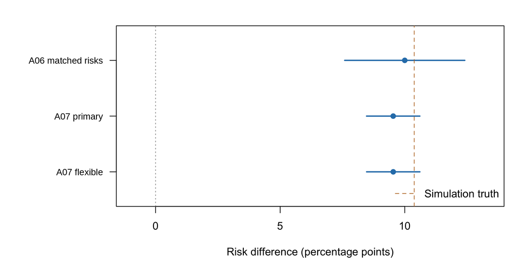

All three estimates use the same matched asthma target.

The true simulated risk difference for the same target population is **10.38 percentage points**. In this sample, the primary model’s estimation error is -0.84 percentage points; adding more model terms does not guarantee that every random sample comes closer to the truth.

Model diagnostics

| Model | rows | pairs | hospitals | parameters | rank | events | converged | min_prediction | max_prediction | covariance_correction |
| --- | --- | --- | --- | --- | --- | --- | --- | --- | --- | --- |
| Primary | 15400 | 7700 | 30 | 45 | 45 | 4120 | TRUE | 0.0148023 | 0.9188062 | 1.037447 |
| Flexible | 15400 | 7700 | 30 | 61 | 61 | 4120 | TRUE | 0.0177426 | 0.9154137 | 1.038529 |

# 5 Repeated-simulation comparison

A06’s 100 positive-effect and 100 null-effect simulations are replayed with the same seeds and sample sizes, and each run is checked against the pair count, the A06 estimate, and the true value. Both A07 models are fitted in each run, and failures are recorded as well.

| Scenario | Method | Successful | Failed | Mean bias (pp) | Coverage | CI excludes zero |
| --- | --- | --- | --- | --- | --- | --- |
| null | A06 | 100 | 0 | 0.61 | 97.0% | 3.0% |
| positive | A06 | 100 | 0 | 0.49 | 98.0% | 100.0% |
| null | A07_flexible | 100 | 0 | 0.32 | 96.0% | 4.0% |
| positive | A07_flexible | 100 | 0 | 0.20 | 95.0% | 100.0% |
| null | A07_main | 100 | 0 | 0.33 | 97.0% | 3.0% |
| positive | A07_main | 100 | 0 | 0.20 | 95.0% | 100.0% |

The total number of failed models is **0**. Coverage and the false-positive share under the null scenario both carry Monte Carlo uncertainty; with only 30 hospitals, the precision of the cluster-robust approximation is also limited.

# 6 Interpretation and limitations

This memo addresses the asthma–control difference in the matched population as a whole. Whether hospital regions show different admission patterns is compared directly in A08. GLM adjustment, within-hospital matching, and sandwich standard errors cannot remove unmeasured confounding in real data; the current results serve only to validate the simulated analysis workflow.

# 7 Reproducibility

The inputs are A06’s result bundle and the same main NACRS cache. The checksums of the two Excel workbooks are checked at A06’s entry point, and A07 additionally checks the A06 results and analysis code. Mathematical checks cover pairing and within-hospital constraints, the hospital-clustered covariance, numerical gradients, consistency of spline predictions, and exclusion of downstream variables from the model.

Back to project home · Matching A06 · Regional analysis A08